# Advanced Tree Models – Boosting Trees

In this lab, we will cover some state-of-the-art techniques in the framework of tree models. We use the same datasets as in previous lab, Boston Housing data and (Taiwan) Credit Card default data (subsample n=12,000 rows).

```r
# load Boston data
library(MASS)
data(Boston)
index <- sample(nrow(Boston),nrow(Boston)*0.60)
boston_train <- Boston[index,]
boston_test <- Boston[-index,]

# load credit card data
credit_data <- read.csv(file = "https://yanyudm.github.io/Data-Mining-R/lecture/data/credit_default.csv", header=T)
# convert categorical variables
credit_data$SEX<- as.factor(credit_data$SEX)
credit_data$EDUCATION<- as.factor(credit_data$EDUCATION)
credit_data$MARRIAGE<- as.factor(credit_data$MARRIAGE)
# random splitting
index <- sample(nrow(credit_data),nrow(credit_data)*0.60)
credit_train = credit_data[index,]
credit_test = credit_data[-index,]
```

# 1 Boosting

Boosting builds a number of small trees, and each time, the response is the residual from last tree. It is a sequential procedure. We use `gbm` package to build boosted trees. Note: The current `gbm` package do not handle asymmetric loss.

## 1.1 Boosting for regression trees

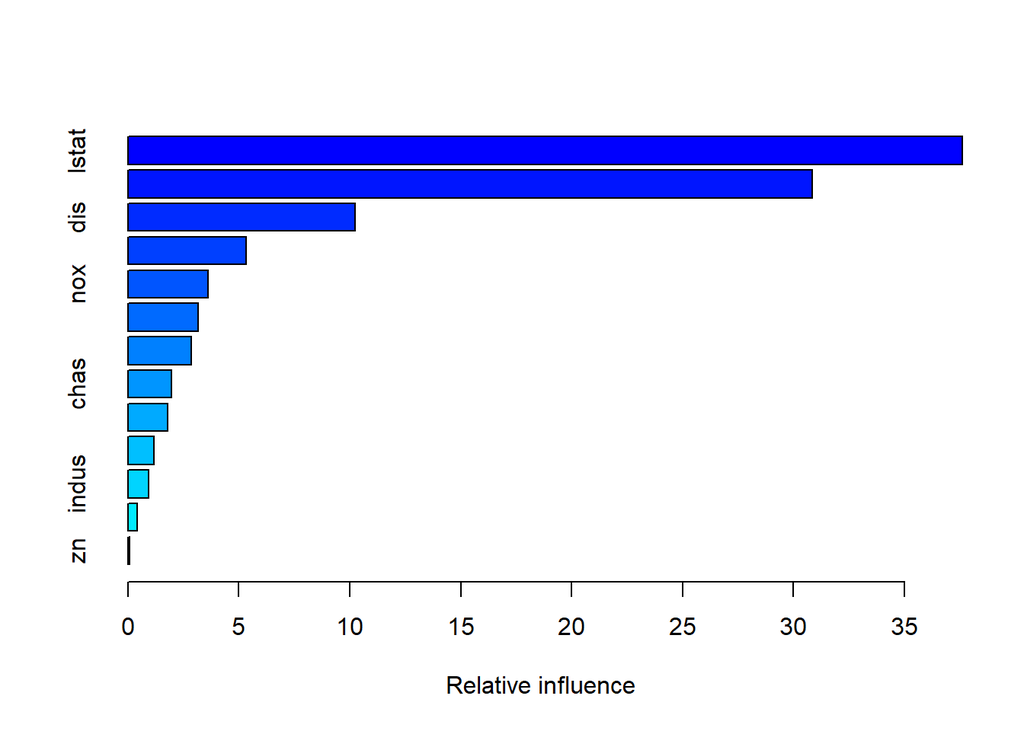

```
##             var     rel.inf
## lstat     lstat 37.61549729
## rm           rm 30.83775837
## dis         dis 10.22990902
## crim       crim  5.31251452
## nox         nox  3.61385727
## black     black  3.16165692
## age         age  2.86512875
## chas       chas  1.96474498
## ptratio ptratio  1.77385053
## tax         tax  1.18471267
## indus     indus  0.93072916
## rad         rad  0.42368402
## zn           zn  0.08595651
```

```r
library(gbm)
# ?gbm
boston_boost<- gbm(formula = medv~.,
                   data = boston_train,
                   distribution = "gaussian",
                   n.trees = 10000,
                   shrinkage = 0.01,
                   interaction.depth = 8)
summary(boston_boost)
```

Note that we need to specify `distribution = "gaussian"` if we are working on regression tree. The default is *Bernoulli* distribution for binary classification problem. `n.trees` is the number of small trees we fit. We need to choose this parameter carefully because it may results in overfitting if the number is too large. `shrinkage` is another tuning parameter that controls how much contribution each tree makes. `interaction.depth` is how many splits of each tree we want. All those tuning parameters can be chosen from cross-validation. The idea is that we don’t want overfitting.

The fitted boosted tree also gives the relation between response and each predictor.

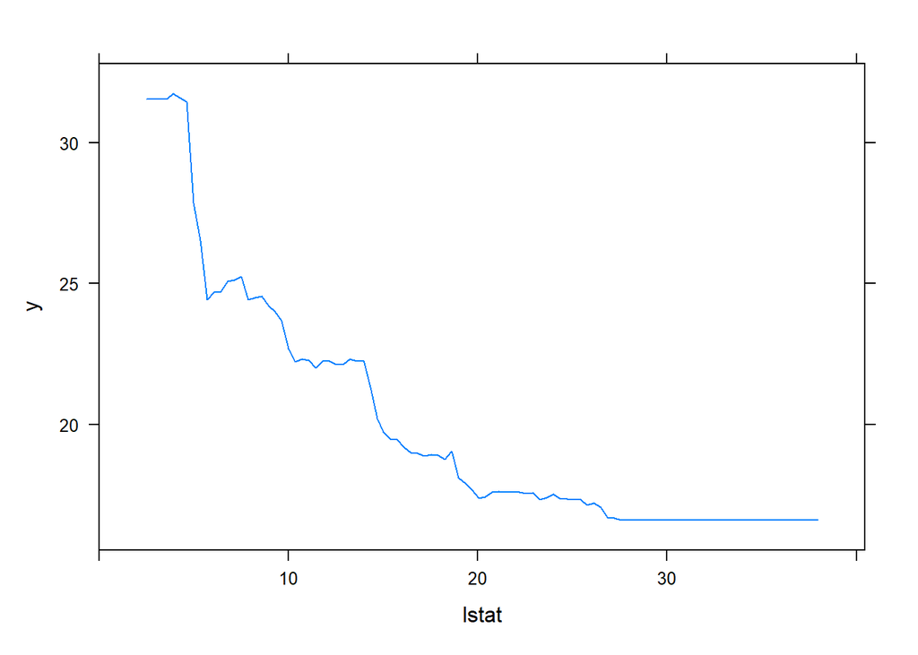

```r
par(mfrow=c(1,2))
plot(boston_boost, i="lstat")
```

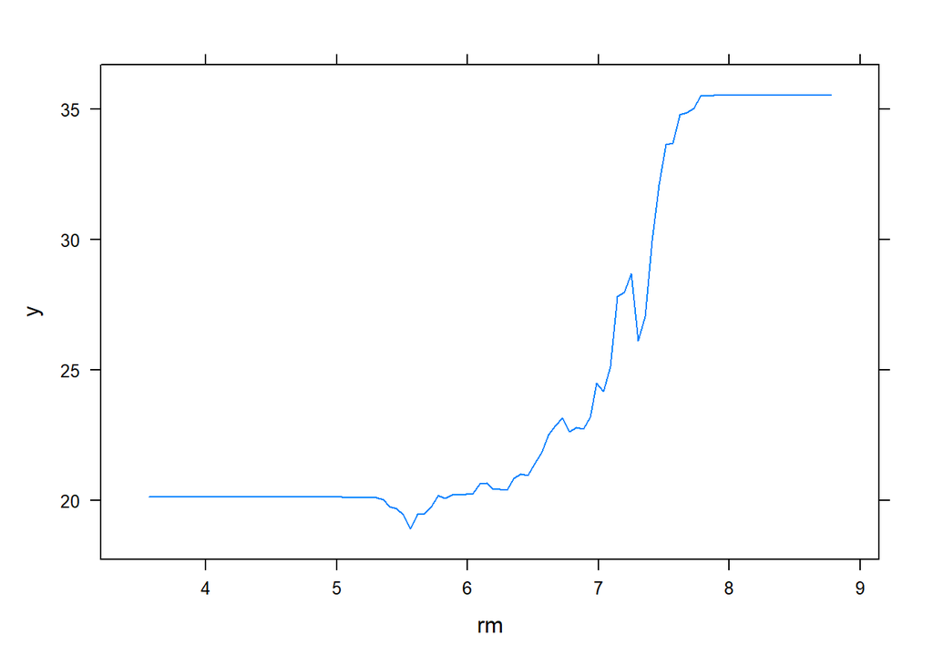

```r
plot(boston_boost, i="rm")
```

Prediction on testing sample.

```r
boston_boost_pred_test<- predict(boston_boost, boston_test, n.trees = 10000)
mean((boston_test$medv-boston_boost_pred_test)^2)
```

```
## [1] 11.13243
```

We can investigate how the testing error changes with different number of trees.

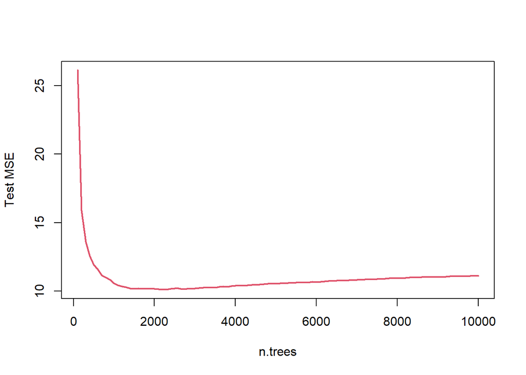

```r
ntree <- seq(100, 10000, 100)
test.err <- rep(0, 13)

predmat <- predict(boston_boost, newdata = boston_test, n.trees = ntree)
err <- apply((predmat-boston_test$medv)^2, 2, mean)
plot(ntree, err, type = 'l', col=2, lwd=2, xlab = "n.trees", ylab = "Test MSE")
abline(h=min(test.err), lty=2)
```

## 1.2 Boosting for classification trees

```r
library(adabag)
credit_train$default.payment.next.month= as.factor(credit_train$default.payment.next.month)
credit_boost= boosting(default.payment.next.month~., data = credit_train, boos = T)
save(credit_boost, file = "credit_boost.Rdata")

# Training AUC
pred_credit_boost= predict(credit_boost, newdata = credit_train)
pred <- prediction(pred_credit_boost$prob[,2], credit_train$default.payment.next.month)
perf <- performance(pred, "tpr", "fpr")
plot(perf, colorize=TRUE)
#Get the AUC
unlist(slot(performance(pred, "auc"), "y.values"))

pred_credit_boost= predict(credit_boost, newdata = credit_test)
# Testing AUC
pred <- prediction(pred_credit_boost$prob[,2], credit_test$default.payment.next.month)
perf <- performance(pred, "tpr", "fpr")
plot(perf, colorize=TRUE)
#Get the AUC
unlist(slot(performance(pred, "auc"), "y.values"))
```

[output not shown]